# Laboratorio 4: Árboles de Decisión — Consultoría SmartStay Advisors

# Actividad 10: Modelo con Validación Cruzada

Se entrena un nuevo modelo utilizando validación cruzada de 10 pliegues (*10-fold cross-validation*) mediante el paquete `caret`, lo que permite obtener una estimación más robusta del desempeño y una selección automática del parámetro de complejidad (`cp`) óptimo.

```r
set.seed(123)

ctrl_cv <- trainControl(
  method     = "cv",
  number     = 10,
  classProbs = TRUE
)

arbol_cv <- train(
  categoria_precio ~ accommodates + bathrooms + bedrooms + beds +
                     room_type + number_of_reviews + minimum_nights,
  data       = train,
  method     = "rpart",
  trControl  = ctrl_cv,
  tuneLength = 10
)

print(arbol_cv)
```

```
## CART
##
## 3500 samples
##    7 predictor
##    3 classes: 'Economica', 'Intermedia', 'Cara'
##
## No pre-processing
## Resampling: Cross-Validated (10 fold)
## Summary of sample sizes: 3149, 3149, 3151, 3150, 3150, 3151, ...
## Resampling results across tuning parameters:
##
##   cp           Accuracy   Kappa
##   0.002440425  0.3303123  -5.076054e-03
##   0.002583979  0.3308821  -4.186192e-03
##   0.002799311  0.3303189  -5.322508e-03
##   0.003014643  0.3294585  -6.820439e-03
##   0.003732415  0.3337418  -7.422163e-04
##   0.003875969  0.3323042  -2.648851e-03
##   0.004306632  0.3363043   3.315236e-03
##   0.005813953  0.3345867  -1.709032e-05
##   0.006029285  0.3345867  -1.709032e-05
##   0.026701120  0.3388553   4.077602e-03
##
## Accuracy was used to select the optimal model using the largest value.
## The final value used for the model was cp = 0.02670112.
```

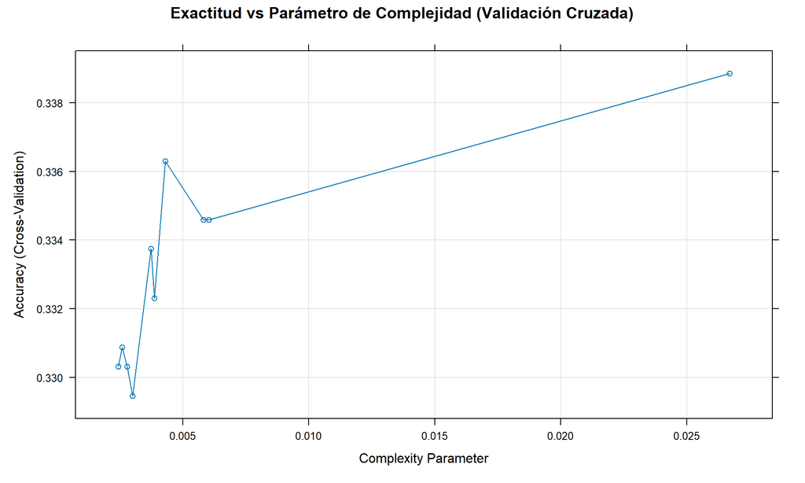

```r
plot(arbol_cv, main = "Exactitud vs Parámetro de Complejidad (Validación Cruzada)")
```

```r
pred_cv <- predict(arbol_cv, newdata = test)

mc_cv <- confusionMatrix(pred_cv, test$categoria_precio)

cat("=== Modelo con Validación Cruzada ===\n")
```

```
## === Modelo con Validación Cruzada ===
```

```r
cat(sprintf("Exactitud: %.2f%%\n", mc_cv$overall["Accuracy"] * 100))
```

```
## Exactitud: 31.27%
```

```r
cat(sprintf("Kappa: %.4f\n", mc_cv$overall["Kappa"]))
```

```
## Kappa: 0.0000
```

```r
cat("\n=== Comparación: Árbol Base vs Validación Cruzada ===\n")
```

```
##
## === Comparación: Árbol Base vs Validación Cruzada ===
```

```r
cat(sprintf("Árbol base (cp=0.01) — Exactitud: %.2f%% | Kappa: %.4f\n",
            mc$overall["Accuracy"] * 100, mc$overall["Kappa"]))
```

```
## Árbol base (cp=0.01) — Exactitud: 31.93% | Kappa: -0.0244
```

```r
cat(sprintf("Validación Cruzada   — Exactitud: %.2f%% | Kappa: %.4f\n",
            mc_cv$overall["Accuracy"] * 100, mc_cv$overall["Kappa"]))
```

```
## Validación Cruzada   — Exactitud: 31.27% | Kappa: 0.0000
```

La validación cruzada permite que el algoritmo evalúe múltiples configuraciones del parámetro de complejidad sobre 10 subconjuntos distintos del entrenamiento, seleccionando automáticamente la configuración que maximiza la exactitud promedio. El modelo resultante tiende a ser más estable y generalizable que un árbol entrenado con un valor fijo de `cp`, ya que reduce el riesgo de sobreajuste a una partición particular de los datos.

# Actividad 11: Tuneo de Profundidad del Árbol de Clasificación

Se construyen al menos tres modelos adicionales variando la profundidad máxima para determinar la configuración óptima del árbol de clasificación.

```r
profundidades <- c(2, 4, 6, 8, 10)
resultados_clas <- data.frame()

for (d in profundidades) {
  modelo_temp <- rpart(
    categoria_precio ~ accommodates + bathrooms + bedrooms + beds +
                       room_type + number_of_reviews + minimum_nights,
    data    = train,
    method  = "class",
    control = rpart.control(maxdepth = d, minsplit = 5, cp = 0.001)
  )

  pred_temp <- predict(modelo_temp, newdata = test, type = "class")
  mc_temp   <- confusionMatrix(pred_temp, test$categoria_precio)

  resultados_clas <- rbind(resultados_clas, data.frame(
    Profundidad = d,
    Exactitud   = round(mc_temp$overall["Accuracy"] * 100, 2),
    Kappa       = round(mc_temp$overall["Kappa"], 4),
    Nodos_hoja  = sum(modelo_temp$frame$var == "<leaf>")
  ))
}

# Agregar modelo base y validación cruzada como referencia
resultados_clas_completo <- rbind(
  data.frame(Modelo = paste("Profundidad", profundidades),
             Exactitud = resultados_clas$Exactitud,
             Kappa = resultados_clas$Kappa,
             Nodos_hoja = resultados_clas$Nodos_hoja),
  data.frame(Modelo = "Árbol base (cp=0.01)",
             Exactitud = round(mc$overall["Accuracy"] * 100, 2),
             Kappa = round(mc$overall["Kappa"], 4),
             Nodos_hoja = sum(arbol_clas$frame$var == "<leaf>")),
  data.frame(Modelo = "Validación Cruzada",
             Exactitud = round(mc_cv$overall["Accuracy"] * 100, 2),
             Kappa = round(mc_cv$overall["Kappa"], 4),
             Nodos_hoja = NA)
)

mejor_clas_idx <- which.max(resultados_clas_completo$Exactitud)

resultados_clas_completo %>%
  kable(caption = "Comparación de árboles de clasificación por profundidad",
        col.names = c("Modelo", "Exactitud (%)", "Kappa", "Nodos hoja"),
        align = "lccc") %>%
  kable_styling(bootstrap_options = c("striped", "hover", "condensed", "responsive"),
                full_width = FALSE) %>%
  row_spec(mejor_clas_idx, bold = TRUE, color = "white", background = "#8E44AD") %>%
  footnote(general = paste("Fila resaltada = mejor exactitud (",
                           resultados_clas_completo$Modelo[mejor_clas_idx], ")"))
```

Comparación de árboles de clasificación por profundidad

|  | Modelo | Exactitud (%) | Kappa | Nodos hoja |
| --- | --- | --- | --- | --- |
| 1 | Profundidad 2 | 32.80 | -0.0137 | 3 |
| 2 | Profundidad 4 | 33.93 | 0.0043 | 11 |
| 3 | Profundidad 6 | 33.20 | 0.0025 | 26 |
| 4 | Profundidad 8 | 31.60 | -0.0256 | 63 |
| 5 | Profundidad 10 | 32.67 | -0.0095 | 105 |
| Accuracy | Árbol base (cp=0.01) | 31.93 | -0.0244 | 2 |
| Accuracy1 | Validación Cruzada | 31.27 | 0.0000 | NA |

Note:  
Fila resaltada = mejor exactitud ( Profundidad 4 )

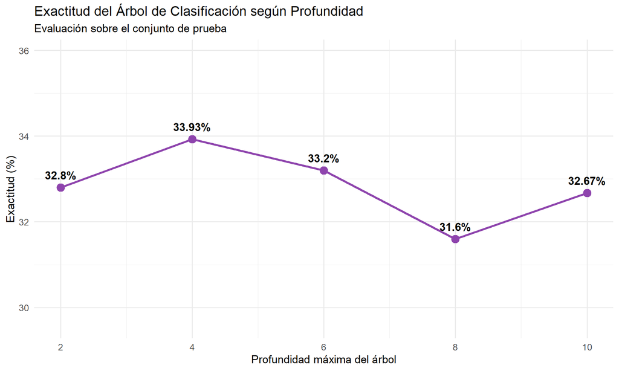

```r
ggplot(resultados_clas, aes(x = Profundidad, y = Exactitud)) +
  geom_line(color = "#8E44AD", size = 1.2) +
  geom_point(size = 4, color = "#8E44AD") +
  geom_text(aes(label = paste0(Exactitud, "%")), vjust = -1, fontface = "bold") +
  labs(title = "Exactitud del Árbol de Clasificación según Profundidad",
       subtitle = "Evaluación sobre el conjunto de prueba",
       x = "Profundidad máxima del árbol", y = "Exactitud (%)") +
  theme_minimal(base_size = 13) +
  ylim(min(resultados_clas$Exactitud) - 2, max(resultados_clas$Exactitud) + 2)
```

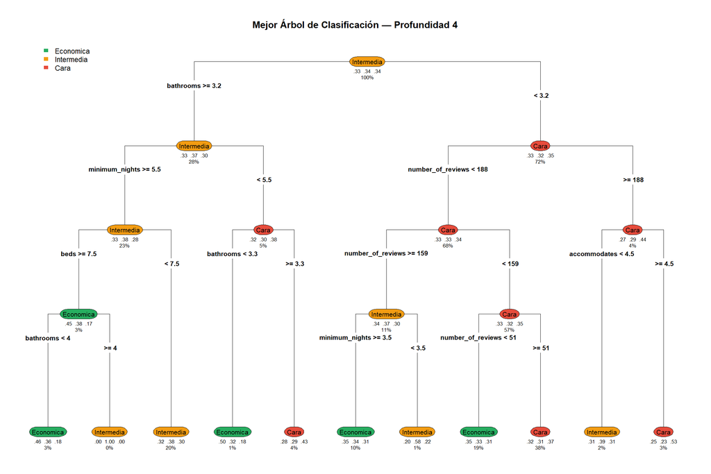

```r
# Reconstruir y visualizar el mejor árbol de clasificación
mejor_prof <- resultados_clas$Profundidad[which.max(resultados_clas$Exactitud)]

arbol_mejor_clas <- rpart(
  categoria_precio ~ accommodates + bathrooms + bedrooms + beds +
                     room_type + number_of_reviews + minimum_nights,
  data    = train,
  method  = "class",
  control = rpart.control(maxdepth = mejor_prof, minsplit = 5, cp = 0.001)
)

rpart.plot(arbol_mejor_clas,
           type = 4, extra = 104, fallen.leaves = TRUE, roundint = FALSE,
           main = paste("Mejor Árbol de Clasificación — Profundidad", mejor_prof),
           box.palette = list("#27AE60", "#F39C12", "#E74C3C"),
           cex = 0.65, under = TRUE)
```

# Actividad 12: Random Forest

Se implementa Random Forest tanto para la tarea de **regresión** (predicción del precio continuo) como para la tarea de **clasificación** (predicción de la categoría de precio), con el objetivo de comparar su desempeño contra los árboles individuales y la regresión lineal.

## 12.1 Random Forest — Regresión

```r
set.seed(123)

# Preparar datos sin NA en las variables seleccionadas
train_rf <- train %>%
  select(price, accommodates, bathrooms, bedrooms, beds,
         room_type, number_of_reviews, minimum_nights) %>%
  drop_na()

test_rf <- test %>%
  select(price, accommodates, bathrooms, bedrooms, beds,
         room_type, number_of_reviews, minimum_nights) %>%
  drop_na()

rf_reg <- randomForest(
  price ~ accommodates + bathrooms + bedrooms + beds +
          room_type + number_of_reviews + minimum_nights,
  data       = train_rf,
  ntree      = 500,
  mtry       = 3,
  importance = TRUE
)

print(rf_reg)
```

```
##
## Call:
##  randomForest(formula = price ~ accommodates + bathrooms + bedrooms +      beds + room_type + number_of_reviews + minimum_nights, data = train_rf,      ntree = 500, mtry = 3, importance = TRUE)
##                Type of random forest: regression
##                      Number of trees: 500
## No. of variables tried at each split: 3
##
##           Mean of squared residuals: 11296.42
##                     % Var explained: -3.84
```

```r
pred_rf_reg <- predict(rf_reg, newdata = test_rf)

rmse_rf <- rmse(test_rf$price, pred_rf_reg)
mae_rf  <- mae(test_rf$price, pred_rf_reg)
r2_rf   <- cor(test_rf$price, pred_rf_reg)^2

cat(sprintf("Random Forest (Regresión) | RMSE: %.2f | MAE: %.2f | R²: %.4f\n",
            rmse_rf, mae_rf, r2_rf))
```

```
## Random Forest (Regresión) | RMSE: 109.18 | MAE: 94.41 | R²: 0.0004
```

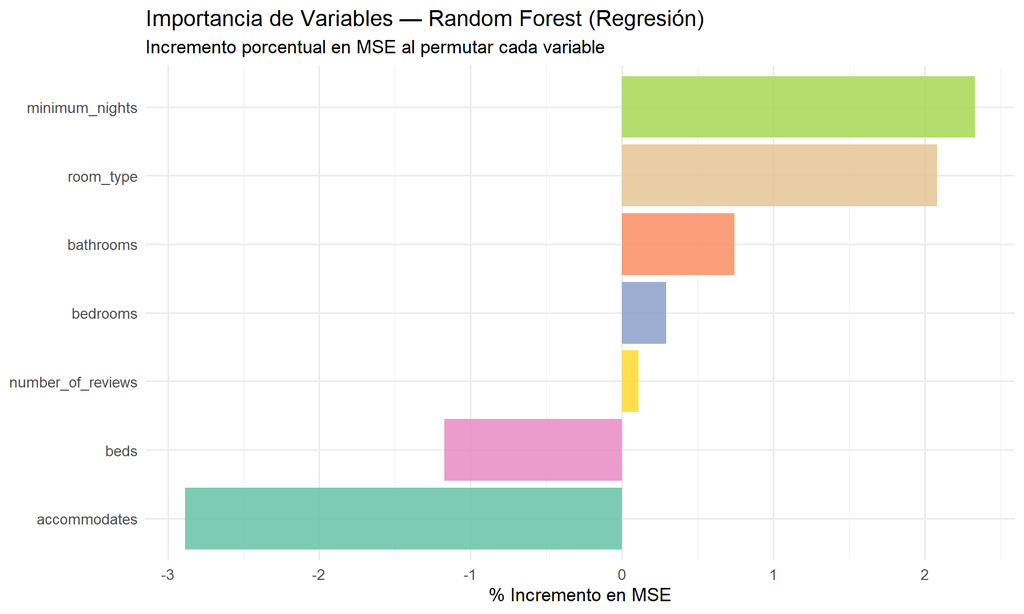

```r
imp_rf <- importance(rf_reg)
imp_rf_df <- data.frame(
  Variable    = rownames(imp_rf),
  Importancia = imp_rf[, "%IncMSE"]
)

ggplot(imp_rf_df, aes(x = reorder(Variable, Importancia), y = Importancia, fill = Variable)) +
  geom_col(alpha = 0.85) +
  coord_flip() +
  scale_fill_brewer(palette = "Set2") +
  labs(title = "Importancia de Variables — Random Forest (Regresión)",
       subtitle = "Incremento porcentual en MSE al permutar cada variable",
       x = NULL, y = "% Incremento en MSE") +
  theme_minimal(base_size = 13) +
  theme(legend.position = "none")
```

## 12.2 Random Forest — Clasificación

```r
set.seed(123)

train_rf_clas <- train %>%
  select(categoria_precio, accommodates, bathrooms, bedrooms, beds,
         room_type, number_of_reviews, minimum_nights) %>%
  drop_na()

test_rf_clas <- test %>%
  select(categoria_precio, accommodates, bathrooms, bedrooms, beds,
         room_type, number_of_reviews, minimum_nights) %>%
  drop_na()

rf_clas <- randomForest(
  categoria_precio ~ .,
  data       = train_rf_clas,
  ntree      = 500,
  mtry       = 3,
  importance = TRUE
)

print(rf_clas)
```

```
##
## Call:
##  randomForest(formula = categoria_precio ~ ., data = train_rf_clas,      ntree = 500, mtry = 3, importance = TRUE)
##                Type of random forest: classification
##                      Number of trees: 500
## No. of variables tried at each split: 3
##
##         OOB estimate of  error rate: 66.54%
## Confusion matrix:
##            Economica Intermedia Cara class.error
## Economica        340        400  408   0.7038328
## Intermedia       360        422  396   0.6417657
## Cara             372        393  409   0.6516184
```

```r
pred_rf_clas <- predict(rf_clas, newdata = test_rf_clas)

mc_rf <- confusionMatrix(pred_rf_clas, test_rf_clas$categoria_precio)
print(mc_rf)
```

```
## Confusion Matrix and Statistics
##
##             Reference
## Prediction   Economica Intermedia Cara
##   Economica        173        150  166
##   Intermedia       181        164  170
##   Cara             160        155  181
##
## Overall Statistics
##
##                Accuracy : 0.3453
##                  95% CI : (0.3213, 0.37)
##     No Information Rate : 0.3447
##     P-Value [Acc > NIR] : 0.488
##
##                   Kappa : 0.0184
##
##  Mcnemar's Test P-Value : 0.295
##
## Statistics by Class:
##
##                      Class: Economica Class: Intermedia Class: Cara
## Sensitivity                    0.3366            0.3497      0.3501
## Specificity                    0.6795            0.6596      0.6796
## Pos Pred Value                 0.3538            0.3184      0.3649
## Neg Pred Value                 0.6627            0.6904      0.6653
## Prevalence                     0.3427            0.3127      0.3447
## Detection Rate                 0.1153            0.1093      0.1207
## Detection Prevalence           0.3260            0.3433      0.3307
## Balanced Accuracy              0.5080            0.5046      0.5148
```

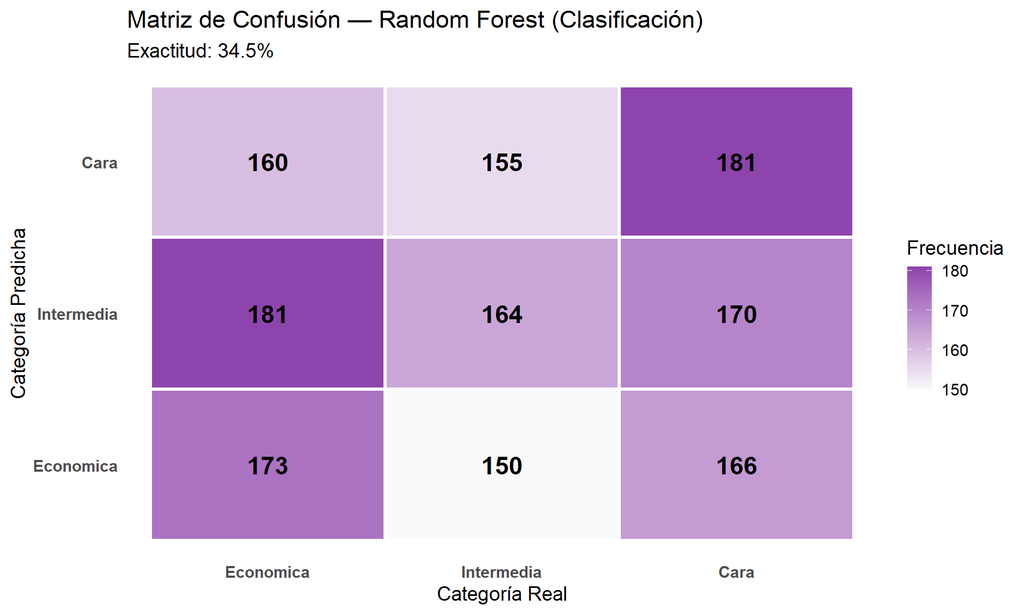

```r
mc_rf_tabla <- as.data.frame(mc_rf$table)

ggplot(mc_rf_tabla, aes(x = Reference, y = Prediction, fill = Freq)) +
  geom_tile(color = "white", size = 1.2) +
  geom_text(aes(label = Freq), size = 6, fontface = "bold") +
  scale_fill_gradient(low = "#F8F9FA", high = "#8E44AD") +
  labs(title = "Matriz de Confusión — Random Forest (Clasificación)",
       subtitle = paste0("Exactitud: ", round(mc_rf$overall["Accuracy"] * 100, 1), "%"),
       x = "Categoría Real", y = "Categoría Predicha", fill = "Frecuencia") +
  theme_minimal(base_size = 14) +
  theme(axis.text = element_text(face = "bold"), panel.grid = element_blank())
```